# Auto Losses and Bikeshare Analysis - Shahin Shakeri

I use R notebooks in RStudio cloud and the data is stored in the clound on my google drive. I submitted this notebook in original format which can be simply be opened in R desktop and run.

# 1- Auto Losses

## 1.a) Two door cars are correlated with more losses

```r
library('lattice')
Autoloss <- read.csv(url("https://drive.google.com/uc?export=download&id=1cbk_KGdo5sfY0c4_ALB5ULTeYQ87uU6k"),na.strings = '?')
Autoloss <-na.omit (Autoloss)
ByDoors=tapply(Autoloss$Losses, Autoloss$NumDoors, mean)
barplot(ByDoors, col = rainbow(15),xlab="Number of Doors",ylab = "Loss",ylim=c(0,150))
```

[output not shown]

## 1.b) Sedans have the lowest losses among the least costly losses. This doesn’t mean the entire dataset follows this pattern.

```r
Lowest<- Autoloss[order(Autoloss$Losses,decreasing=FALSE),][1:10,]
Lowest<-tapply(Lowest$Losses,Lowest$BodyStyle , mean)
Lowest
```

[output not shown]

## 1.c) Sedans and Hatchbacks have the widest spread of losses. The losses in sedan are skewed towards the lower end where in the other styles are more or less evenly distributed.

```r
ByWheels<-tapply(Autoloss$Losses,Autoloss$BodyStyle,mean)
ByWheels
boxplot(Losses~BodyStyle,data=Autoloss ,col = rainbow(15))
```

[output not shown]

## 1.d) Lower priced car have costlier loses than higher priced cars on average

```r
xyplot(Losses~Price,data=Autoloss, col = rainbow(50))
```

[output not shown]

# 2 -Bikeshare

## 2.a) We run a simple regression for Rentals~Temperature

```r
Bikeshare <- read.csv(url("https://drive.google.com/uc?export=download&id=1jtfh-qmyDM3l_nU3AkPP_ZsepL-jHW8I"),na.strings = '?')
LModel=lm(Rentals~Temperature,data=Bikeshare)
{plot(Bikeshare$Temperature,Bikeshare$Rentals,col='blue')
abline(LModel,col="red" )}
```

[output not shown]

```r
summary(LModel)
```

[output not shown]

## For every 1 change to normalized Temperature, Rentals change by 6640.7. Accoring to small p <.05 this is significant

## 2.b) We run a simple regression for Rentals~Humidity

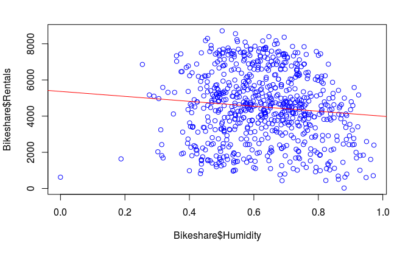

```r
LModel=lm(Rentals~Humidity,data=Bikeshare)
{plot(Bikeshare$Humidity,Bikeshare$Rentals,col='blue')
abline(LModel,col="red" )}
```

```r
summary(LModel)
```

```
Call:
lm(formula = Rentals ~ Humidity, data = Bikeshare)

Residuals:
    Min      1Q  Median      3Q     Max
-4741.0 -1386.9    50.3  1439.3  4036.8

Coefficients:
            Estimate Std. Error t value Pr(>|t|)
(Intercept)   5364.0      322.7  16.623  < 2e-16 ***
Humidity     -1369.1      501.2  -2.732  0.00645 **
---
Signif. codes:  0 ‘***’ 0.001 ‘**’ 0.01 ‘*’ 0.05 ‘.’ 0.1 ‘ ’ 1

Residual standard error: 1929 on 729 degrees of freedom
Multiple R-squared:  0.01013,   Adjusted R-squared:  0.008774
F-statistic: 7.462 on 1 and 729 DF,  p-value: 0.006454
```

## For every 1 increase to normalized Humidity, Rentals change by -1369.1/100 . Accoring to small p <.05 this is significant but the R-squared: 0.01013 shows this is not a good model

## 2.c) We run a simple regression for Rentals~Windspeed

```r
LModel=lm(Rentals~Windspeed,data=Bikeshare)
{plot(Bikeshare$Windspeed,Bikeshare$Rentals,col='blue')
abline(LModel,col="red" )}
```

[output not shown]

```r
summary(LModel)
```

[output not shown]

## For every 1 increase to Windspeed, Rentals change by -5862.9/69. Accoring to small p <.05 this is significant but R-squared: 0.05501 shows this is not significant

#3 Multiple Linear Regression

## 3.a)

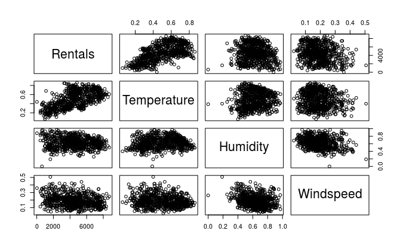

```r
pairs(Rentals~Temperature+ Humidity +Windspeed ,data=Bikeshare)
```

## 3.b) We use a multivar regression model

```r
model <- lm(Rentals~Temperature+ Humidity +Windspeed ,data=Bikeshare)
```

```r
summary(model)
```

```
Call:
lm(formula = Rentals ~ Temperature + Humidity + Windspeed, data = Bikeshare)

Residuals:
    Min      1Q  Median      3Q     Max
-4780.5 -1082.6   -62.2  1056.5  3653.5

Coefficients:
            Estimate Std. Error t value Pr(>|t|)
(Intercept)   4084.4      337.9  12.089  < 2e-16 ***
Temperature   6625.5      293.1  22.606  < 2e-16 ***
Humidity     -3100.1      384.0  -8.073 2.83e-15 ***
Windspeed    -4806.9      708.9  -6.781 2.48e-11 ***
---
Signif. codes:  0 ‘***’ 0.001 ‘**’ 0.01 ‘*’ 0.05 ‘.’ 0.1 ‘ ’ 1

Residual standard error: 1425 on 727 degrees of freedom
Multiple R-squared:  0.4609,    Adjusted R-squared:  0.4587
F-statistic: 207.2 on 3 and 727 DF,  p-value: < 2.2e-16
```

## In the order of p value Temperature,Humidity and Windspeed have the highest impact/

## 3.c)

```r
predict(model,new_day,interval='confidence')
```

```
       fit      lwr      upr
1 6082.941 5848.711 6317.171
```